# Appendix

## 1 📂 Project Sections

### 1.1 🔹 Core Pages

- **Executive Summary**  
  Overview of the project goals, data source (AWSD), key research questions, and why analyzing violence against aid workers matters.
- **Data Cleaning**  
  Details on how the raw data was processed for analysis, including missing value handling and variable selection.
- **Global Analysis**  
  A global-level analysis of trends, followed by the identification of countries with the highest number of security incidents for deeper investigation.
- **Exploring the Unknown**  
  Investigates patterns of missing or “Unknown” data in security reports, revealing systematic information gaps by country and attribute.

### 1.2 🌍 Individual Country Analysis

Country-specific deep dives, each including historical context, temporal and spatial trends, attack characteristics, casualty patterns, and strategic recommendations:

- **🇵🇸 Palestine**  
  Focus on the October 2023 escalation and impacts of aerial bombardment on aid operations in Gaza and the West Bank.
- **🇦🇫 Afghanistan**  
  Tracks violence across regimes—from Taliban rule to NATO presence to the current Islamic Emirate—highlighting shifts in targeting patterns.
- **🇨🇩 DR Congo**  
  Explores complex violence in eastern DRC driven by armed groups, with a focus on mobility risks and localized conflict dynamics.
- **🇸🇾 Syria**  
  Analyzes conflict phases from civil war to regime collapse in 2024, with emphasis on aerial attacks and frontline crossfire incidents.
- **🇸🇴 Somalia**  
  Details threats from Al-Shabaab, patterns of ambushes and kidnappings, and the impact of climate shocks on humanitarian security.
- **🇲🇱 Mali**  
  Highlights post-coup violence, the rise in kidnapping, and the shift from international to local staff exposure following MINUSMA withdrawal.
- **🇸🇸 South Sudan**  
  Investigates intercommunal conflict, targeted attacks on convoys, and the relationship between aid presence and violence.
- **🇸🇩 Sudan**  
  Focuses on the humanitarian fallout from the 2023 civil war, including documentation challenges and increasing targeting of aid facilities.

### 1.3 🤖 LLM Useage Log

- **LLM Log**  
  A running log of how large language models were used throughout the project for analysis, text generation, and research assistance.

### 1.4 Commit History

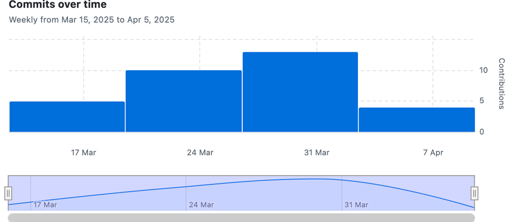